# Dose-response curve fitting for CE, ALE and IR events

Mario Keller

Faculty of Biological Sciences, Goethe University Frankfurt

15 June 2023

```r
library(tidyverse)
library(readxl)
library(knitr)
library(ggpubr)
library(ggsci)
library(drc)
library(aomisc)
library(Gviz)
library(GenomicFeatures)
```

```r
myTheme <- theme_bw() +
    theme(axis.text = element_text(size = 14, colour="black"),
          axis.title = element_text(size=16, colour="black"),
          axis.ticks=element_line(color="black"),
          axis.ticks.length=unit(.15, "cm"),
          panel.border=element_rect(color="black", fill = NA),
          panel.background = element_blank(),
          plot.background = element_blank(),
          legend.text = element_text(size=12),
          legend.position = "none")
```

```r
projectDir <- "/Users/mariokeller/projects/HNRNPH_project/Tretow_et_al_2023"

majiqDir <- paste0(projectDir, "/2_MAJIQ_AS_analysis")
drcDir <- paste0(projectDir, "/3_Dose_response_curve_fitting")
dataDir <- paste0(projectDir, "/data")
```

# 1 Background

Based on the MAJIQ quantifications, dose-response curves should be fitted for each CE, ALE and IR event identified as regulated in *MAJIQ_AS_analysis.Rmd*. The purpose of the fitting is to identify coopreatively regulated events based on the fitted Hill coefficient (nH). Events with an absolute Hill coefficient > 1 are expected to show a switch-like splicing response in dependence on HNRNPH protein levels.

# 2 Data

Regulated cassette exon (CE), alternative last exon (ALE) and intron retention (IR) events are loaded from RDS-Files created in *MAJIQ_AS_analysis.Rmd*. The loaded data.frames contain the PSI and $\Delta$PSI quantifications as well as additional meta information.

```r
regulatedCEs <- readRDS(paste0(majiqDir,"/rds_files/regulatedCEs.rds"))
regulatedALEs <- readRDS(paste0(majiqDir,"/rds_files/regulatedALEs.rds"))
regulatedIRs <- readRDS(paste0(majiqDir,"/rds_files/regulatedIRs.rds"))
```

Here is the number of regulated events per AS event class for which a fitting is performed:

- CE events: 447
- ALE events: 71
- IR events: 276

# 3 Dose-response curve fitting

## 3.1 Preparation

The relative protein concentration of replicates is averaged for each knockdown and overexpression condition. Protein levels were measured by Western Blot analysis and signals of knockdown and overexpression experiments normalized to their matched controls.

Here are the used concentrations:

```r
proteinConcKD <- c(KD_10000=mean(c(54,39)), KD_05000=mean(c(51,47)),
                   KD_01000=mean(c(54,49,76)), KD_00500=mean(c(80,68,98)),
                   KD_00250=mean(c(84,80,91)), KD_00100=mean(c(102,98,81)),
                   KD_00050=mean(c(95,114,81)))

proteinConcOE <- c(OE_00600=mean(c(134.8948469, 107.5182327, 123.7675621)),
                   OE_01000=mean(c(129.0983149, 139.7401286, 161.1825442)),
                   OE_02500=mean(c(142.8957191, 143.8951726, 242.539298)))

proteinConc <- c(proteinConcKD, Contr=100, proteinConcOE)
rm(proteinConcKD, proteinConcOE)

# This block creates a table for the html output
proteinConc %>%
    as.data.frame() %>%
    tibble::rownames_to_column(var="condition") %>%
    dplyr::rename(., relative_concentration = .) %>%
    kable(., "html") %>%
    kableExtra::kable_styling("striped") %>%
    kableExtra::scroll_box(height="300px", width = "94%")
```

| condition | relative_concentration |
| --- | --- |
| KD_10000 | 46.50000 |
| KD_05000 | 49.00000 |
| KD_01000 | 59.66667 |
| KD_00500 | 82.00000 |
| KD_00250 | 85.00000 |
| KD_00100 | 93.66667 |
| KD_00050 | 96.66667 |
| Contr | 100.00000 |
| OE_00600 | 122.06021 |
| OE_01000 | 143.34033 |
| OE_02500 | 176.44340 |

In addition, vectors with comparison and sample names are defined.

```r
comparisons <- c("KD_10000", "KD_05000", "KD_01000", "KD_00500", "KD_00250",
                 "KD_00100", "KD_00050", "OE_00600", "OE_01000", "OE_02500")

samples <- c(paste0("KD_10000_", 1:2), paste0("KD_05000_", 1:2), paste0("KD_01000_", 1:3),
             paste0("KD_00500_", 1:3), paste0("KD_00250_", 1:3), paste0("KD_00100_", 1:3),
             paste0("KD_00050_", 1:3), paste0("KD_Contr_", 1:3), paste0("OE_Contr_", 1:3),
             paste0("OE_00600_", 1:3), paste0("OE_01000_", 1:3), paste0("OE_02500_", 1:3))
```

For each event a LL.4() is fitted using the formula dPSI~proteinConc. In addition, lower and upper boundaries were set for the parameters to be fitted:

- nH (the Hill coefficient): -Inf to +Inf (no constraints)
- ec50: 0 to +Inf (concentration can not be negative)
- min: -max(ContrPSI)* to 0
- max: 0 to 1-min(ContrPSI)*

* ContrPSI is a numeric vector of length 2 containing the PSI value of the knockdown and overexpression control for the fitted event

The output is a drc model object to which meta information is added, namely the event identifier, the name of the underlying gene as well as a goodness-of-fit metric called pseudoR2, which is later used for the removal of bad fittings.

The fitting and the plotting of dose-response curves is implemented in functions that are called *fitDRC()* and *plotDRC()*, respectively.

```r
# Input is the unique event identifier as well as one of the regulation
#   data.frames (regulatedCEs, regulatedALEs and regulatedIRs)
fitDRC <- function(eventID, regulatedDf){

    # Extract the name of the underlying gene
    gene_name <- regulatedDf %>% filter(event_id == eventID) %>% pull(gene_name)

    # In this block the dPSI values of the event are extracted.Setting comparison
    #   as factor is needed to bring the dPSIs in the correct order via arrange()
    dPSI <- regulatedDf %>% filter(event_id == eventID) %>%
    dplyr::select(ends_with("median_dpsi")) %>%
    pivot_longer(everything(), names_to = "comparison") %>%
    mutate(comparison=strsplit(comparison, ".", fixed=T) %>% sapply(., "[[", 1)) %>%
    mutate(comparison=factor(comparison, levels=comparisons)) %>%
    arrange(comparison) %>%
    pull(value)

    # The dPSI of the Control is set to 0 and inserted between KD_00050
    #   (position 7) and OE_00600 (position 8)
    dPSI <- c(dPSI[1:7], 0, dPSI[8:10])

    # PSIs of the two controls are extracted. These are needed to define
    #   the lower and upper limits of the min and max parameter, respectively.
    ContrPSI <- regulatedDf %>% filter(event_id == eventID) %>%
        dplyr::select(ends_with("Contr_median_psi")) %>%
        pivot_longer(everything()) %>%
        pull(value)

    # The protein concentrations and the dPSI values are combined in
    #   a data.frame that is used as input for the drm() function.
    fittingDf <- data.frame(proteinConc, dPSI)

    # The drm() function fits the LL.4(). paramter constraints are defined
    #   via lowerl and upperl.
    m <- drm(
        formula = dPSI ~ proteinConc, data = fittingDf,
        fct = LL.4(names = c("nH", "min", "max", "ec50")),
        lowerl=c(-Inf, -(max(ContrPSI)), 0, 0),
        upperl=c(Inf, 0, 1-min(ContrPSI), Inf))

    # Meta information is added to the model object. R2nls() of the aomisc
    #   package is used to compute the pseudoR2 metric
    m$event_id <- eventID
    m$gene_name <- gene_name
    m$nH <- coef(m)[1]
    m$min <- coef(m)[2]
    m$max <- coef(m)[3]
    m$ec50 <- coef(m)[4]
    m$pseudoR2 <- R2nls(m)$PseudoR2

    return(m)
}

# Input is a drm model. In addition, the user defines the color and size of the
#   points as well as the aspect ratio.
plotDRC <- function(m, myCol = "#DC0000FF", pointSize = 3, aspectRatio = 1){

    # The model is used to predict dPSI values based on the provided values
    fittedData <- data.frame(x=seq(46,177,1),
                             y=predict(m, data.frame(proteinConc=seq(46,177,1))))

    # Fitted values are shown as geom_line() and the original data points as
    #   geom_points(). The original data points can be extracted from the model.
    ggplot(fittedData,aes(x=x,y=y)) +
        geom_point(data=m$origData, aes(x=proteinConc, y=dPSI), pch=21,
                   fill=myCol, size=pointSize) +
        geom_line(size=1) +
        labs(x="Protein concentration (%)", y=expression(Delta*PSI),
             title=paste0(m$event_id, " - ",
                          m$gene_name, "\nnH=", round(m$nH,1),
                          " - EC50=", round(m$ec50,1),
                          " - pR2=", round(m$pseudoR2,2))) +
        myTheme +
        theme(plot.title = element_text(size=6), aspect.ratio = aspectRatio)
}
```

## 3.2 Results

The fitting is performed for the regulated CE, ALE and IR events.

```r
# For each event the fitDRC() function is executed
fittedCEs <- lapply(regulatedCEs$event_id, fitDRC, regulatedCEs) %>%
    setNames(., regulatedCEs$event_id)
fittedALEs <- lapply(regulatedALEs$event_id, fitDRC, regulatedALEs) %>%
    setNames(., regulatedALEs$event_id)
fittedIRs <- lapply(regulatedIRs$event_id, fitDRC, regulatedIRs) %>%
    setNames(., regulatedIRs$event_id)
```

Individual summaries are prepared for CEs, ALEs and IRs. The Top5 fitting results are shown (ordered by descending pseudoR2).

```r
# The data.frames comprise for each event the fitted parameters and
#   additional information

# For each event class the Top5 fitted events are shown in a table in
#   the html output

summaryCEs <- data.frame(event_id=names(fittedCEs),
                         gene_name=sapply(fittedCEs, "[[", "gene_name"),
                         nH=sapply(fittedCEs, "[[", "nH"),
                         ec50=sapply(fittedCEs, "[[", "ec50"),
                         min=sapply(fittedCEs, "[[", "min"),
                         max=sapply(fittedCEs, "[[", "max"),
                         pseudoR2=sapply(fittedCEs, "[[", "pseudoR2"))

summaryCEs %>%
    arrange(dplyr::desc(pseudoR2)) %>%
    dplyr::slice(1:5) %>%
    kable(., "html", align="c", caption="Fitted cassette exon events") %>%
    kableExtra::kable_styling("striped") %>%
    kableExtra::scroll_box(height="300px", width = "94%")
```

Table 1: Fitted cassette exon events

| event_id | gene_name | nH | ec50 | min | max | pseudoR2 |
| --- | --- | --- | --- | --- | --- | --- |
| ENSG00000205302.7_1_CE_1 | SNX2 | 27.00773 | 143.2425 | -0.0772826 | 0.0000000 | 1.0000000 |
| ENSG00000141198.16_2_CE_1 | TOM1L1 | 19.28250 | 54.2062 | 0.0000000 | 0.0662762 | 0.9999999 |
| ENSG00000170836.13_1_CE_1 | PPM1D | 44.65124 | 142.6966 | -0.0799767 | 0.0000000 | 0.9999991 |
| ENSG00000115234.11_2_CE_1 | SNX17 | 39.57706 | 143.6418 | -0.0709334 | 0.0000000 | 0.9999961 |
| ENSG00000108010.12_2_CE_1 | GLRX3 | 31.88794 | 182.5301 | -0.2405039 | 0.0000000 | 0.9999937 |

```r
summaryALEs <- data.frame(event_id=names(fittedALEs),
                          gene_name=sapply(fittedALEs, "[[", "gene_name"),
                          nH=sapply(fittedALEs, "[[", "nH"),
                          ec50=sapply(fittedALEs, "[[", "ec50"),
                          min=sapply(fittedALEs, "[[", "min"),
                          max=sapply(fittedALEs, "[[", "max"),
                          pseudoR2=sapply(fittedALEs, "[[", "pseudoR2"))

summaryALEs %>%
    arrange(dplyr::desc(pseudoR2)) %>%
    dplyr::slice(1:5) %>%
    kable(., "html", align="c", caption="Fitted alternative last exon events") %>%
    kableExtra::kable_styling("striped") %>%
    kableExtra::scroll_box(height="300px", width = "94%")
```

Table 1: Fitted alternative last exon events

| event_id | gene_name | nH | ec50 | min | max | pseudoR2 |
| --- | --- | --- | --- | --- | --- | --- |
| ENSG00000105202.9_1_ale_1 | FBL | 12.49844 | 148.46611 | -0.2097368 | 0.0001891 | 0.9999170 |
| ENSG00000096872.17_2_ale_1 | IFT74 | 20.83003 | 53.82192 | 0.0000000 | 0.1917354 | 0.9956798 |
| ENSG00000143379.13_4_ale_1 | SETDB1 | 25.05994 | 45.01142 | -0.0001081 | 0.3519014 | 0.9871583 |
| ENSG00000187017.18_3_ale_1 | ESPN | 62.69014 | 47.60222 | -0.0001142 | 0.4576875 | 0.9844187 |
| ENSG00000169592.15_2_ale_4 | INO80E | -32.44545 | 83.87318 | -0.2417011 | 0.0013302 | 0.9833560 |

```r
summaryIRs <- data.frame(event_id=names(fittedIRs),
                         gene_name=sapply(fittedIRs, "[[", "gene_name"),
                         nH=sapply(fittedIRs, "[[", "nH"),
                         ec50=sapply(fittedIRs, "[[", "ec50"),
                         min=sapply(fittedIRs, "[[", "min"),
                         max=sapply(fittedIRs, "[[", "max"),
                         pseudoR2=sapply(fittedIRs, "[[", "pseudoR2"))

summaryIRs %>%
    arrange(dplyr::desc(pseudoR2)) %>%
    dplyr::slice(1:5) %>%
    kable(., "html", align="c", caption="Fitted intron retention events") %>%
    kableExtra::kable_styling("striped") %>%
    kableExtra::scroll_box(height="300px", width = "94%")
```

Table 1: Fitted intron retention events

| event_id | gene_name | nH | ec50 | min | max | pseudoR2 |
| --- | --- | --- | --- | --- | --- | --- |
| ENSG00000167767.14_2_AI_1 | KRT80 | 29.34338 | 44.99316 | 0.0000000 | 0.1850613 | 0.9999991 |
| ENSG00000131473.17_2_AI_1 | ACLY | 22.56250 | 45.18326 | 0.0000000 | 0.2532925 | 0.9999630 |
| ENSG00000169045.17_3_AI_10 | HNRNPH1 | 14.22512 | 136.24213 | -0.3186966 | 0.0003122 | 0.9998241 |
| ENSG00000074211.14_3_AI_1 | PPP2R2C | 19.98052 | 45.48539 | 0.0000000 | 0.2398083 | 0.9993463 |
| ENSG00000142208.18_2_AI_1 | AKT1 | 15.69804 | 54.36467 | -0.0006601 | 0.0826084 | 0.9993362 |

As a proof of concept the fitted dose-response curve of the 11th exon of MST1R/RON is shown, which nicely matches the dose-response curve shown in Figure 6b in [Braun et al.](https://www.nature.com/articles/s41467-018-05748-7), which was based on qRT-PCR measurements.

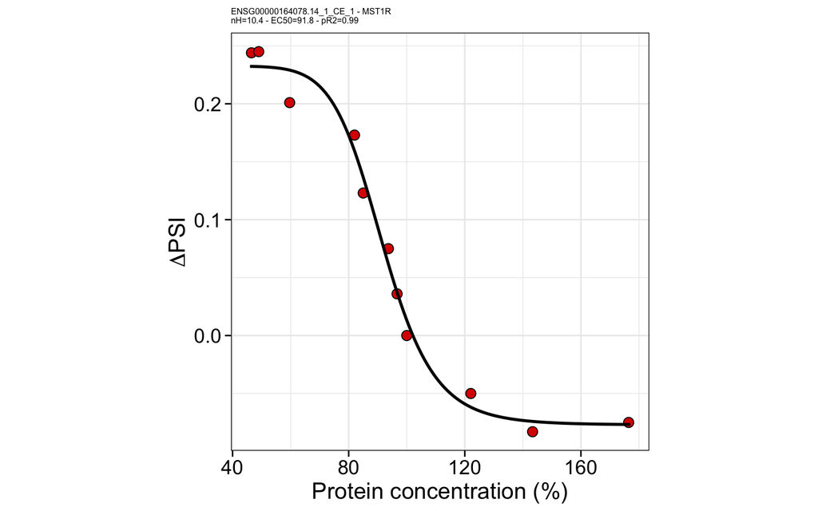

```r
plotDRC(fittedCEs$ENSG00000164078.14_1_CE_1)
```

# 4 Filtering by pseudoR2

As mentioned above for each fitted dose-response curve the pseudoR2 was computed, which serves as a measure for the goodness-of-fit. Before applying a cut-off, the pseudo R2 distribution was visualized for the fitted CE, ALE and IR events. The later applied cut-off of 0.75 is added as a vertical line.

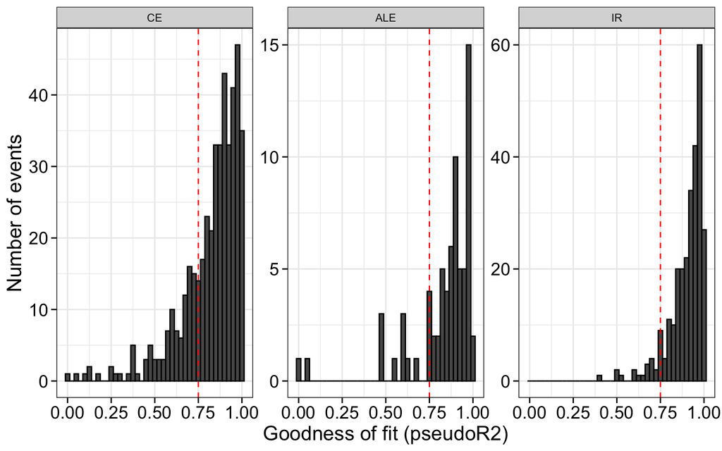

```r
# First a data.frame with an event class column and a pseudoR2 column is
#   created and piped into the ggplot() function to create a facet_wrap
#   of histograms.
data.frame(event=factor(c(rep("CE", nrow(summaryCEs)),
                          rep("ALE", nrow(summaryALEs)),
                          rep("IR", nrow(summaryIRs))),
                        levels=c("CE", "ALE", "IR")),
           pseudoR2=c(summaryCEs$pseudoR2,
                      summaryALEs$pseudoR2,
                      summaryIRs$pseudoR2)) %>%
    ggplot(., aes(x=pseudoR2)) +
    geom_histogram(binwidth = 0.025, col="black") +
    facet_wrap(~event, scales="free_y") +
    geom_vline(xintercept = 0.75, col="red", linetype="dashed") +
    scale_x_continuous(breaks=seq(0,1,0.25)) +
    labs(x= "Goodness of fit (pseudoR2)", y="Number of events") +
    myTheme
```

Events with a pseudoR2 < 0.75 are removed to ensure a high quality of fitted events.

```r
# Apply the filtering
filteredFittedCEs <- fittedCEs[fittedCEs %>% sapply(., "[[", "pseudoR2") >= 0.75]
filteredFittedALEs <- fittedALEs[fittedALEs %>% sapply(., "[[", "pseudoR2") >= 0.75]
filteredFittedIRs <- fittedIRs[fittedIRs %>% sapply(., "[[", "pseudoR2") >= 0.75]
```

Here is the the number of events after applying the filtering:

- CEs: 331
- ALEs: 60
- IRs: 257

# 5 Categorization by the Hill coefficient

The individual events should be categorized based on their fitted Hill coefficient (nH). As a first step, the distribution of Hill coefficients was plotted for the three event classes. Coefficients less than -25 or greater than 25 were set to -25 and 25, respectively.

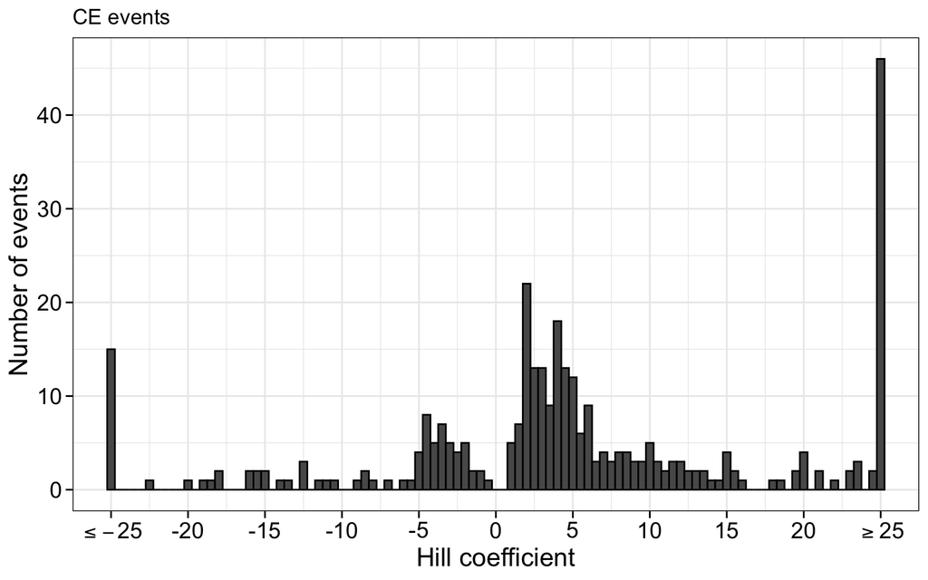

```r
# For each of the three event classes a Hill coefficient histogram is
#   plotted. Coefficients were limited to -25 and 25.

data.frame(nH=sapply(filteredFittedCEs, "[[", "nH")) %>%
    mutate(nH=ifelse(nH > 25, 25, nH)) %>%
    mutate(nH=ifelse(nH < -25, -25, nH)) %>%
    ggplot(aes(x=nH)) +
    geom_histogram(binwidth = .5, col="black") +
    coord_cartesian(xlim=c(-25, 25)) +
    scale_x_continuous(breaks=seq(-25, 25, 5),
                       labels=c(expression(""<=-25), "-20", "-15", "-10", "-5", "0",
                                "5", "10", "15", "20", expression("">=25))) +
    labs(x="Hill coefficient", y="Number of events", title= "CE events") +
    myTheme
```

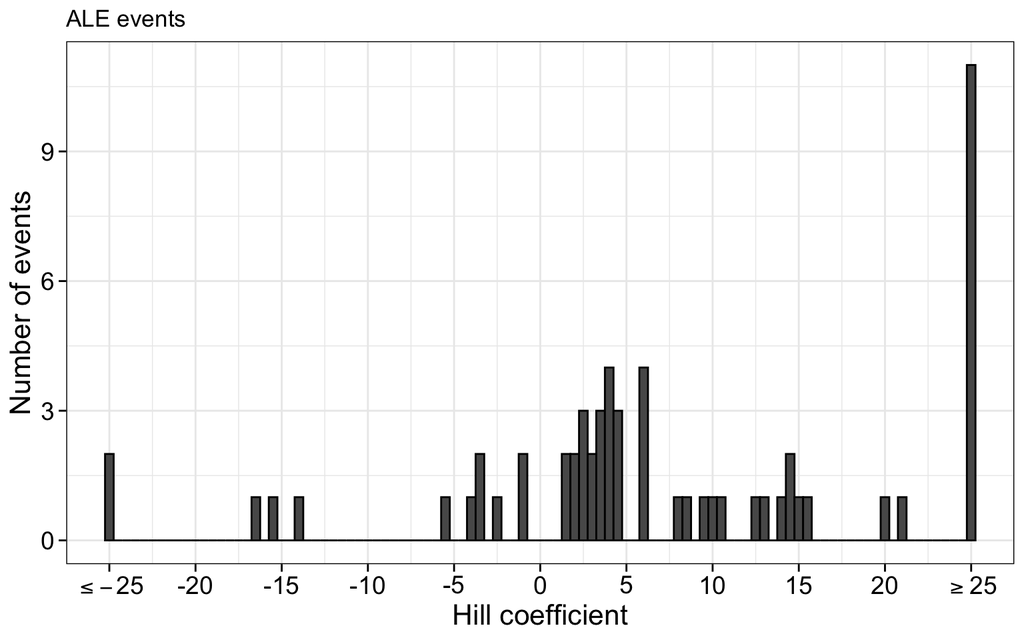

```r
data.frame(nH=sapply(filteredFittedALEs, "[[", "nH")) %>%
    mutate(nH=ifelse(nH > 25, 25, nH)) %>%
    mutate(nH=ifelse(nH < -25, -25, nH)) %>%
    ggplot(aes(x=nH)) +
    geom_histogram(binwidth = .5, col="black") +
    coord_cartesian(xlim=c(-25, 25)) +
    scale_x_continuous(breaks=seq(-25, 25, 5),
                       labels=c(expression(""<=-25), "-20", "-15", "-10", "-5", "0",
                                "5", "10", "15", "20", expression("">=25))) +
    labs(x="Hill coefficient", y="Number of events", title= "ALE events") +
    myTheme
```

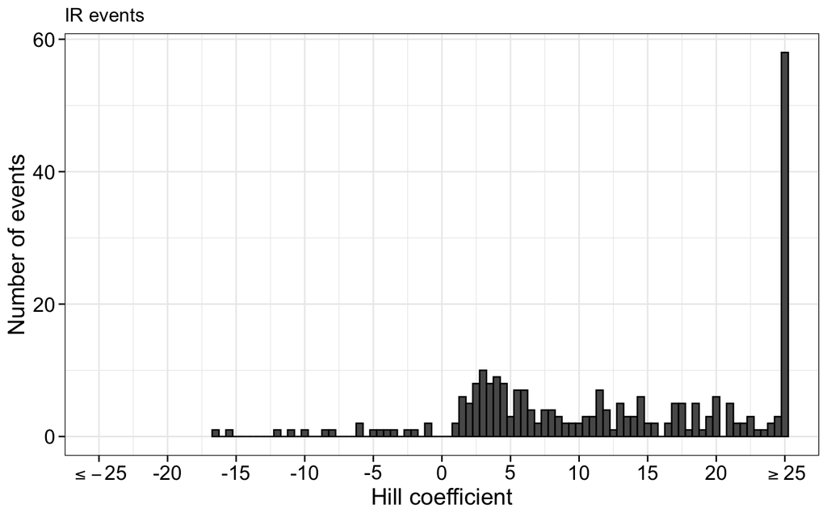

```r
data.frame(nH=sapply(filteredFittedIRs, "[[", "nH")) %>%
    mutate(nH=ifelse(nH > 25, 25, nH)) %>%
    mutate(nH=ifelse(nH < -25, -25, nH)) %>%
    ggplot(aes(x=nH)) +
    geom_histogram(binwidth = .5, col="black") +
    coord_cartesian(xlim=c(-25, 25)) +
    scale_x_continuous(breaks=seq(-25, 25, 5),
                       labels=c(expression(""<=-25), "-20", "-15", "-10", "-5", "0",
                                "5", "10", "15", "20", expression("">=25))) +
    labs(x="Hill coefficient", y="Number of events", title= "IR events") +
    myTheme
```

Each event is assigned to one of four groups based on the fitted Hill coefficient. There are two cooperative (Coop) and two non-cooperative (nonCoop) groups with one containing enhanced (Enh) and one repressed (Rep) events. Enhanced events show more inclusion when HNRNPH levels are high, while repressed events show reduced inclusion when HNRNPH levels are high.

These are the four groups and the Hill coefficient thresholds:

- Coop-Enh: nH <= -2
- non-Coop-Enh: -2 < nH <0
- non-Coop-Rep: 0 <= nH < 2
- Coop-Rep: 2 <= nH

```r
# Based on the Hill coefficient (nH), events are assigned to one
#   of four groups.

filteredFittedCEs <- lapply(filteredFittedCEs, function(m){
    if(2 <= m$nH){m$hillCat <- "Coop-Rep"}
    else if(0<= m$nH & m$nH < 2){m$hillCat <- "nonCoop-Rep"}
    else if(-2 < m$nH & m$nH < 0){m$hillCat <- "nonCoop-Enh"}
    else{m$hillCat <- "Coop-Enh"}
    return(m)
})

filteredFittedALEs <- lapply(filteredFittedALEs, function(m){
    if(2 <= m$nH){m$hillCat <- "Coop-Rep"}
    else if(0<= m$nH & m$nH < 2){m$hillCat <- "nonCoop-Rep"}
    else if(-2 < m$nH & m$nH < 0){m$hillCat <- "nonCoop-Enh"}
    else{m$hillCat <- "Coop-Enh"}
    return(m)
})

filteredFittedIRs <- lapply(filteredFittedIRs, function(m){
    if(2 <= m$nH){m$hillCat <- "Coop-Rep"}
    else if(0<= m$nH & m$nH < 2){m$hillCat <- "nonCoop-Rep"}
    else if(-2 < m$nH & m$nH < 0){m$hillCat <- "nonCoop-Enh"}
    else{m$hillCat <- "Coop-Enh"}
    return(m)
})
```

In the plot below the number of events assigned to one of the four categories is shown for the CE, ALE and IR event class.

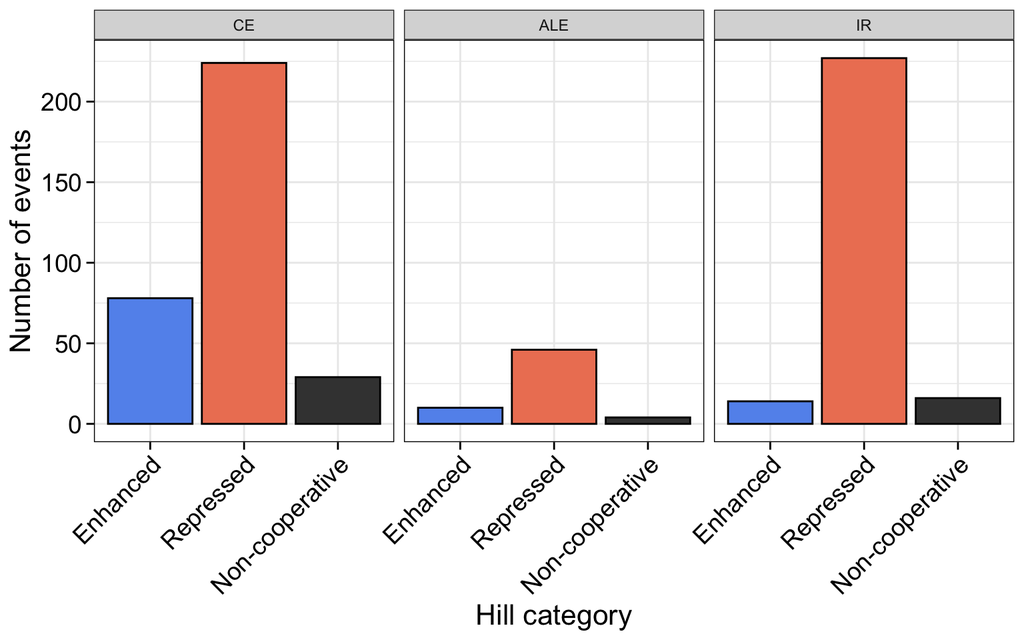

```r
# Count the number of events per category for each AS event class and combine
#   the resulting data.frames via rbind(). The resulting data.frame is adjusted
#   and used as input for ggplot() to plot a facet_wrap of barcharts.

rbind(
    sapply(filteredFittedCEs, "[[", "hillCat") %>%
        table(., dnn="hillCat") %>%
        as.data.frame %>%
        mutate(event="CE"),
    sapply(filteredFittedALEs, "[[", "hillCat") %>%
        table(., dnn="hillCat") %>%
        as.data.frame %>%
        mutate(event="ALE"),
    sapply(filteredFittedIRs, "[[", "hillCat") %>%
        table(., dnn="hillCat") %>%
        as.data.frame %>%
        mutate(event="IR")
) %>%
    mutate(event=factor(event, levels = c("CE", "ALE", "IR"))) %>%
    mutate(hillCat=case_when(hillCat == "Coop-Enh" ~ "Enhanced",
                             hillCat == "Coop-Rep" ~ "Repressed",
                             TRUE ~ "Non-cooperative")) %>%
    group_by(event, hillCat) %>%
    dplyr::summarize(Freq = sum(Freq)) %>%
    mutate(hillCat=factor(hillCat, levels=c("Enhanced", "Repressed", "Non-cooperative"))) %>%
    ggplot(., aes(x=hillCat, y=Freq, fill=hillCat)) +
    geom_col(col="black") +
    facet_wrap(~event) +
    theme_bw() +
    scale_fill_manual(values=c("Enhanced" = "cornflowerblue", "Repressed" = "salmon2", "Non-cooperative" = "#404040")) +
    theme_bw() +
    labs(x="Hill category", y="Number of events") +
    myTheme +
    theme(axis.text.x = element_text(angle=45, vjust = 1, hjust = 1))
```

For all three types of events, Coop-Rep (cooperatively repressed) is the most covered category, which reflects the repressor function of HNRNPH on those events under control conditions.

As a small example the fitting of one CE event per category is shown:

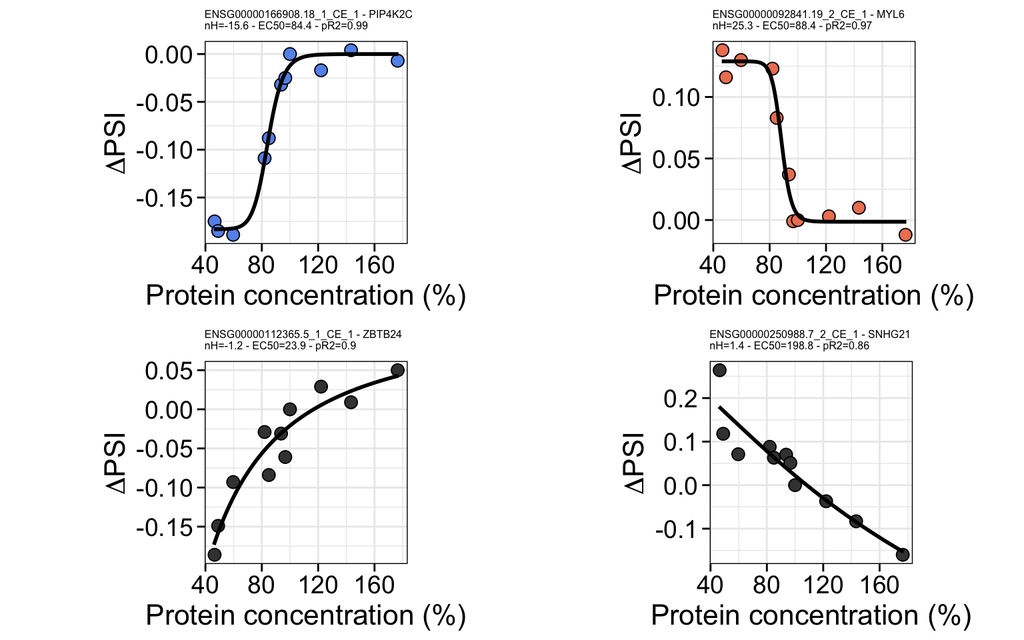

```r
# Four events are selected and the plots of their fitted dose-response curves
#   combined via ggarrange().
ggarrange(
    plotDRC(filteredFittedCEs$ENSG00000166908.18_1_CE_1, "cornflowerblue"),
    plotDRC(filteredFittedCEs$ENSG00000092841.19_2_CE_1, "salmon2"),
    plotDRC(filteredFittedCEs$ENSG00000112365.5_1_CE_1, "#404040"),
    plotDRC(filteredFittedCEs$ENSG00000250988.7_2_CE_1, "#404040"),
    ncol=2, nrow=2
)
```

# 6 Validation by qRT-PCR

Kerstin Tretow from the IMB performed qRT-PCR measurements of the four events in response to the HNRNPH titration, followed by dose-response cuver fitting. For 3 of the 4 events the results were verified. The fourth event could not be measured as the expression of the underlying gene was too low.

The PSI measurements for the *PIP4K2C*, *MYL6* and *SNHG21* events are loaded, replicate PSIs are averaged and $\Delta$PSIs computed by subtracting the matched control PSIs from the knockdown and overexpression PSIs. At the end the $\Delta$PSIs are combined with the relative protein concentrations into a data.frame for each of the three events.

```r
# Load the Excel sheet of each event into a data.frame
xlsx_path <- paste0(dataDir,"/qRT_PCR_DRC_validation/zusammenfassung_Titrationvalidation_Mario.xlsx")
qRT_PSIs <- list(PIP4K2C = read_xlsx(xlsx_path, sheet="PIP4K2C"),
             MYL6 = read_xlsx(xlsx_path, sheet="MYL6"),
             SNHG21 = read_xlsx(xlsx_path, sheet="SNHG21"))

# dPSIs are computed by first averaging the replicate PSIs, followed by the
#   computation of dPSIs by subtracting the PSIs of the matched controls
#   from the knockdown and overexpression PSIs. The control PSIs are at
#   position 8 and 9 in the PSI column.

qRT_dPSIs <- lapply(qRT_PSIs, function(df){
  df <- df %>% dplyr::filter(!(Treatment %in% c("10000 nM", "5000 nM") & Replicate == 3))
  treatmentLevels <- df$Treatment %>% unique
  df <- df %>%
    group_by(Treatment) %>%
    dplyr::summarise(Treatment=unique(Treatment), PSI=mean(PSI)) %>%
    mutate(Treatment=factor(Treatment, levels=treatmentLevels)) %>%
    arrange(Treatment)
  df$dPSI <- NA
  df$dPSI[1:8] <- df$PSI[1:8] - df$PSI[8]
  df$dPSI[9:12] <- df$PSI[9:12] - df$PSI[9]
  df <- df[-9,]
  df$proteinConc <- proteinConc
  return(df)
})
```

In the following, for each event the dose-response curve is fitted and meta information added to each model. Fitting was done without any parameter constraints.

```r
# For each of the three events a dose-response curve is fitted and additional
#   information added to the models

PIP4K2Cmodel <- drm(
  formula = dPSI ~ proteinConc, data = qRT_dPSIs$PIP4K2C,
  fct = LL.4(names = c("nH", "min", "max", "ec50")))
PIP4K2Cmodel$nH <- coef(PIP4K2Cmodel)[1]
PIP4K2Cmodel$min <- coef(PIP4K2Cmodel)[2]
PIP4K2Cmodel$max <- coef(PIP4K2Cmodel)[3]
PIP4K2Cmodel$ec50 <- coef(PIP4K2Cmodel)[4]
PIP4K2Cmodel$pseudoR2 <- R2nls(PIP4K2Cmodel)$PseudoR2
PIP4K2Cmodel$name <- "PIP4K2C"
PIP4K2Cmodel$event_id <- "ENSG00000166908.18_1_CE_1"


MYL6model <- drm(
  formula = dPSI ~ proteinConc, data = qRT_dPSIs$MYL6,
  fct = LL.4(names = c("nH", "min", "max", "ec50")))
MYL6model$nH <- coef(MYL6model)[1]
MYL6model$min <- coef(MYL6model)[2]
MYL6model$max <- coef(MYL6model)[3]
MYL6model$ec50 <- coef(MYL6model)[4]
MYL6model$pseudoR2 <- R2nls(MYL6model)$PseudoR2
MYL6model$name <- "MYL6"
MYL6model$event_id <- "ENSG00000092841.19_2_CE_1"


SNHG21model <- drm(
  formula = dPSI ~ proteinConc, data = qRT_dPSIs$SNHG21,
  fct = LL.4(names = c("nH", "min", "max", "ec50")))
SNHG21model$nH <- coef(SNHG21model)[1]
SNHG21model$min <- coef(SNHG21model)[2]
SNHG21model$max <- coef(SNHG21model)[3]
SNHG21model$ec50 <- coef(SNHG21model)[4]
SNHG21model$pseudoR2 <- R2nls(SNHG21model)$PseudoR2
SNHG21model$name <- "SNHG21"
SNHG21model$event_id <- "ENSG00000250988.7_2_CE_1"
```

The fitted dose-response curves using qRT-PCR measurements nicely resemble the fitted dose-reponse curves using RNA-seq measurements.

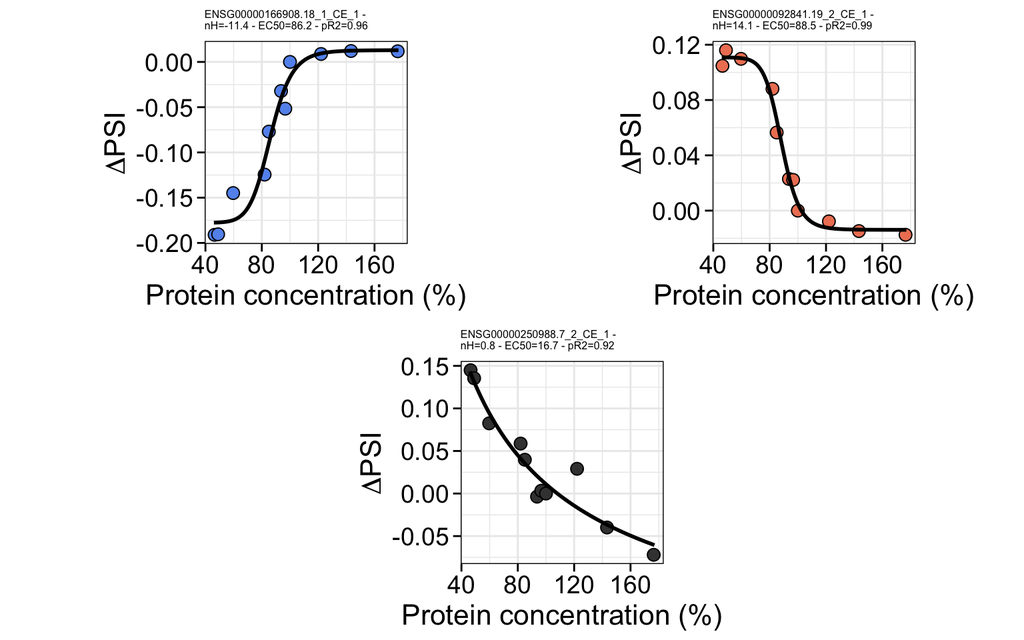

```r
# The plots of their fitted dose-response curves are combined via ggarrange().
#   The ggarrange() calls within ggarrange() are necessary to align the bottom
#   plot to the center

ggarrange(
    ggarrange(
        plotDRC(PIP4K2Cmodel, "cornflowerblue"),
        plotDRC(MYL6model, "salmon2"),
        ncol=2
        ),
    ggarrange(NULL,
              plotDRC(SNHG21model, "#404040"),
              NULL,
              ncol=3
              ),
    ncol=1, nrow=2
)
```

# 7 Browser shots

As a final step for *PIP4K2C* (Coop-Enh) and *MYL6* (Coop-Rep) browser shots are generated showing the merged RNA-seq data of the strongest knockdown and the matched control as well as the strongest overexpression and the matched control. The original BAM-Files have been subsetted to the genomic regions of *PIP4K2C* and *MYL6*, respectively, using *samtools view*.

As selected transcript isoforms should be shown in the annotation track, the GENCODE annotation v39 is loaded and subsetted to entries with selected transcript identifiers of *PIP4K2C* and *MYL6*.

The coverage on the cassette and flanking exons nicely reflect the results of the dose-response cuves, namely an increased coverage on the cassette exon of *MYL6* in the strongest knockdown and a reduced coverage on the cassette exon of *PIP4K2C* in thre strongest knockdown.

```r
# The annotation is loaded from a Gzip-File.
anno <- rtracklayer::import(paste0(dataDir, "/gencode.v39.annotation.gff3.gz"))

anno <- anno[which(anno$transcript_id %in% c("ENST00000422156.7",
                                             "ENST00000348108.8",
                                             "ENST00000293422.9"))]
# Turn it into a TxDB
annoTxdb <- makeTxDbFromGRanges(anno)
```

## 7.1 PIP4K2C - ENSG00000166908.18_1_CE_1

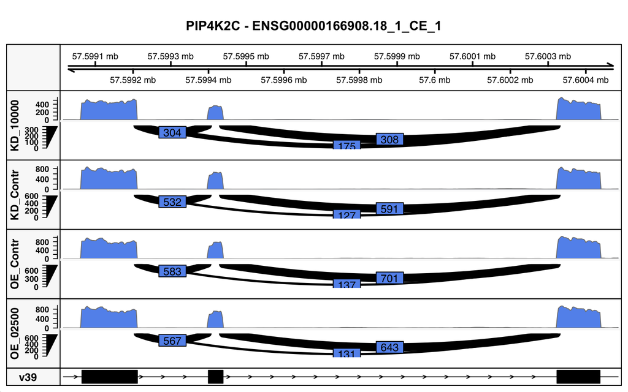

```r
# Define the junctions that should be shown in the browser shot
sashimiFilterRanges <- GRanges(seqnames = Rle(c("chr12")),
                               IRanges(c(57599211+1, 57599438+1, 57599211+1),
                                       c(57599400-1, 57600324-1, 57600324-1)))

# Alignment tracks are created for the four conditions
KD_10000_tr <- AlignmentsTrack(paste0(dataDir,
                                      "/BAM/KD_10000_merged_PIP4K2C.bam"),
                               name="KD_10000",
                               fill="cornflowerblue",
                               coverageOnly=TRUE,
                               sashimiFilter=sashimiFilterRanges)
KD_Contr_tr <- AlignmentsTrack(paste0(dataDir,
                                      "/BAM/KD_Contr_merged_PIP4K2C.bam"),
                               name="KD_Contr",
                               fill="cornflowerblue",
                               coverageOnly=TRUE,
                               sashimiFilter=sashimiFilterRanges)
OE_Contr_tr <- AlignmentsTrack(paste0(dataDir,
                                      "/BAM/OE_Contr_merged_PIP4K2C.bam"),
                               name="OE_Contr",
                               fill="cornflowerblue",
                               coverageOnly=TRUE,
                               sashimiFilter=sashimiFilterRanges)
OE_2500_tr <- AlignmentsTrack(paste0(dataDir,
                                     "/BAM/OE_02500_merged_PIP4K2C.bam"),
                              name="OE_02500",
                              fill="cornflowerblue",
                              coverageOnly=TRUE,
                              sashimiFilter=sashimiFilterRanges)

# Also a GeneRegion track is generated
anno_tr <- GeneRegionTrack(annoTxdb, name = "v39", col="black", fill="black",
                           col.line="black", rotation.title=0)

# The Browser shot is created for the genomic region where the CE event
#   is located.
plotTracks(list(GenomeAxisTrack(col="black", fontcolor="black"),
                KD_10000_tr, KD_Contr_tr, OE_Contr_tr, OE_2500_tr, anno_tr),
           from= 57599065 - 50,
           to=57600437 + 50, # long last exon
           chromosome = "chr12",
           type = c("coverage", "sashimi"),
           fontsize=10,
           sizes = c(2,3,3,3,3,0.75),
           sashimiNumbers = TRUE,
           frame=TRUE,
           main="PIP4K2C - ENSG00000166908.18_1_CE_1",
           cex.main=1,
           cex.axis=0.75,
           cex.title=1,
           col.axis="black",
           col.sashimi="black",
           background.title="#f9f9f9",
           col.border.title="black",
           fontcolor.title="black",
           col.frame="black")
```

## 7.2 MYL6 - ENSG00000092841.19_2_CE_1

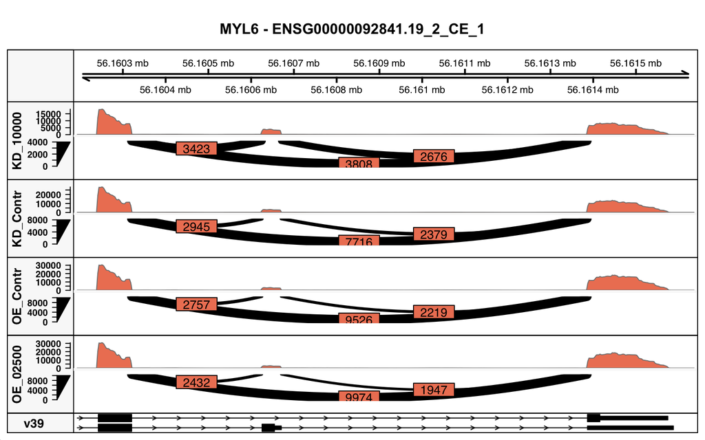

```r
# Define the junctions that should be shown in the browser shot
sashimiFilterRanges <- GRanges(seqnames = Rle(c("chr12")),
                               IRanges(c(56160320+1, 56160670+1, 56160320+1),
                                       c(56160626-1, 56161387-1, 56161387-1)))

# Alignment tracks are created for the four conditions
KD_10000_tr <- AlignmentsTrack(paste0(dataDir,
                                      "/BAM/KD_10000_merged_MYL6.bam"),
                               name="KD_10000",
                               fill="salmon2",
                               coverageOnly=TRUE,
                               sashimiFilter=sashimiFilterRanges)
KD_Contr_tr <- AlignmentsTrack(paste0(dataDir,
                                      "/BAM/KD_Contr_merged_MYL6.bam"),
                               name="KD_Contr",
                               fill="salmon2",
                               coverageOnly=TRUE,
                               sashimiFilter=sashimiFilterRanges)
OE_Contr_tr <- AlignmentsTrack(paste0(dataDir,
                                      "/BAM/OE_Contr_merged_MYL6.bam"),
                               name="OE_Contr",
                               fill="salmon2",
                               coverageOnly=TRUE,
                               sashimiFilter=sashimiFilterRanges)
OE_2500_tr <- AlignmentsTrack(paste0(dataDir,
                                     "/BAM/OE_02500_merged_MYL6.bam"),
                              name="OE_02500",
                              fill="salmon2",
                              coverageOnly=TRUE,
                              sashimiFilter=sashimiFilterRanges)

# The Browser shot is created for the genomic region where the CE event
#   is located.
plotTracks(list(GenomeAxisTrack(col="black", fontcolor="black"),
                KD_10000_tr, KD_Contr_tr, OE_Contr_tr, OE_2500_tr, anno_tr),
           from= 56160243 - 50,
           to=56161587 + 50, # long last exon
           chromosome = "chr12",
           type = c("coverage", "sashimi"),
           fontsize=10,
           sizes = c(2,3,3,3,3,0.75),
           sashimiNumbers = TRUE,
           frame=TRUE,
           main="MYL6 - ENSG00000092841.19_2_CE_1",
           cex.main=1,
           cex.axis=0.75,
           cex.title=1,
           col.axis="black",
           col.sashimi="black",
           background.title="#f9f9f9",
           col.border.title="black",
           fontcolor.title="black",
           col.frame="black")
```

# 8 Output

The final sets of fitted CE, ALE and IR events are stored in RDS-Files for further analyses.

```r
saveRDS(filteredFittedCEs, paste0(drcDir,"/rds_files/fittedCEs.rds"))
saveRDS(filteredFittedALEs, paste0(drcDir,"/rds_files/fittedALEs.rds"))
saveRDS(filteredFittedIRs, paste0(drcDir,"/rds_files/fittedIRs.rds"))
```